# Quiz Two

```r
rm(list=ls())
```

# 1 Q1

Load the Alzheimer’s disease data using the commands:

```r
library(AppliedPredictiveModeling)
data(AlzheimerDisease)
```

Which of the following commands will create non-overlapping training and test sets with about 50% of the observations assigned to each?

```r
adData = data.frame(diagnosis,predictors)
testIndex = createDataPartition(diagnosis, p = 0.50,list=FALSE)
training = adData[-testIndex,]
testing = adData[testIndex,]
```

# 2 Q2

Load the cement data using the commands:

```r
library(AppliedPredictiveModeling)
data(concrete)
library(caret)
set.seed(1000)
inTrain = createDataPartition(mixtures$CompressiveStrength, p = 3/4)[[1]]
training = mixtures[ inTrain,]
testing = mixtures[-inTrain,]
```

Make a plot of the outcome (CompressiveStrength) versus the index of the samples. Color by each of the variables in the data set (you may find the cut2() function in the Hmisc package useful for turning continuous covariates into factors). What do you notice in these plots?

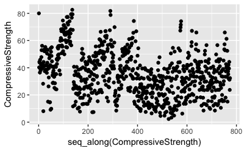

```r
qplot(y=CompressiveStrength,data=training)
```

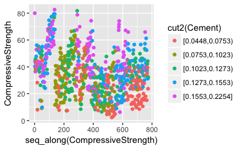

```r
qplot(y=CompressiveStrength,data=training,colour=cut2(Cement))
```

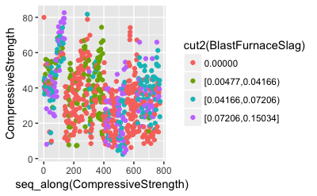

```r
qplot(y=CompressiveStrength,data=training,colour=cut2(BlastFurnaceSlag))
```

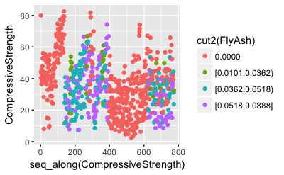

```r
qplot(y=CompressiveStrength,data=training,colour=cut2(FlyAsh))
```

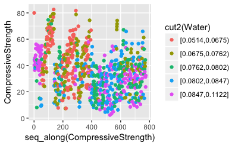

```r
qplot(y=CompressiveStrength,data=training,colour=cut2(Water))
```

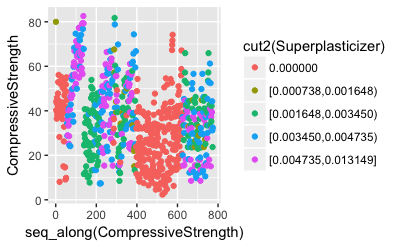

```r
qplot(y=CompressiveStrength,data=training,colour=cut2(Superplasticizer))
```

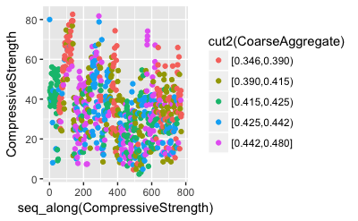

```r
qplot(y=CompressiveStrength,data=training,colour=cut2(CoarseAggregate))
```

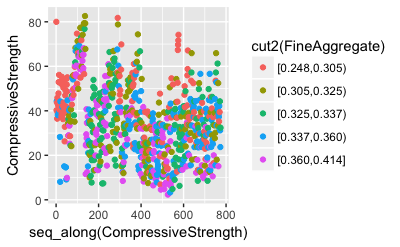

```r
qplot(y=CompressiveStrength,data=training,colour=cut2(FineAggregate))
```

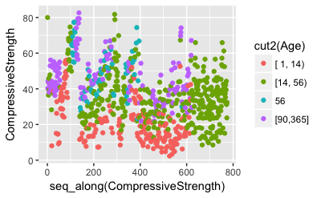

```r
qplot(y=CompressiveStrength,data=training,colour=cut2(Age))
```

There is a non-random pattern in the plot of the outcome versus index that does not appear to be perfectly explained by any predictor suggesting a variable may be missing.

# 3 Q3

Load the cement data using the commands:

```r
library(AppliedPredictiveModeling)
data(concrete)
library(caret)
set.seed(1000)
inTrain = createDataPartition(mixtures$CompressiveStrength, p = 3/4)[[1]]
training = mixtures[ inTrain,]
testing = mixtures[-inTrain,]
```

Make a histogram and confirm the SuperPlasticizer variable is skewed. Normally you might use the log transform to try to make the data more symmetric. Why would that be a poor choice for this variable?

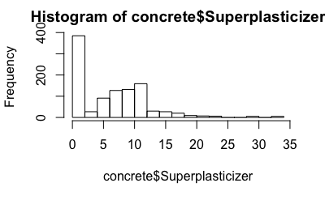

```r
hist(concrete$Superplasticizer)
```

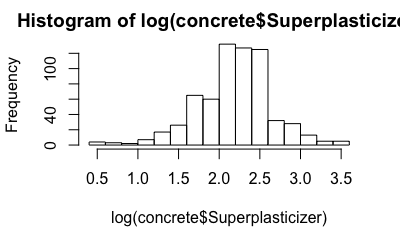

```r
hist(log(concrete$Superplasticizer))
```

```r
zeros <- grepl('0', concrete$Superplasticizer)
table(zeros)
```

```
zeros
FALSE  TRUE
  588   442
```

```r
log(0)
```

```
[1] -Inf
```

There are values of zero so when you take the log() transform those values will be -Inf.

# 4 Q4

Load the Alzheimer’s disease data using the commands:

```r
library(caret)
library(AppliedPredictiveModeling)
set.seed(3433)
data(AlzheimerDisease)
adData = data.frame(diagnosis,predictors)
inTrain = createDataPartition(adData$diagnosis, p = 3/4)[[1]]
training = adData[ inTrain,]
testing = adData[-inTrain,]
```

Find all the predictor variables in the training set that begin with IL. Perform principal components on these variables with the preProcess() function from the caret package. Calculate the number of principal components needed to capture 90% of the variance. How many are there?

```r
ILcols <- grepl('^[Ii][Ll].*', colnames(training))
table(ILcols)
```

```
ILcols
FALSE  TRUE
  119    12
```

```r
#create principal components
preProc <- preProcess((training[,ILcols]),method = "pca",thresh = .90)
preProc
```

```
Created from 251 samples and 12 variables

Pre-processing:
  - centered (12)
  - ignored (0)
  - principal component signal extraction (12)
  - scaled (12)

PCA needed 9 components to capture 90 percent of the variance
```

9 components.

# 5 Q5

Load the Alzheimer’s disease data using the commands:

```r
library(caret)
library(AppliedPredictiveModeling)
set.seed(3433)
data(AlzheimerDisease)
adData = data.frame(diagnosis,predictors)
inTrain = createDataPartition(adData$diagnosis, p = 3/4)[[1]]
training = adData[ inTrain,]
testing = adData[-inTrain,]
```

Create a training data set consisting of only the predictors with variable names beginning with IL and the diagnosis. Build two predictive models, one using the predictors as they are and one using PCA with principal components explaining 80% of the variance in the predictors. Use method=“glm” in the train function.

```r
#Setup data
ILcols <- grepl('^[Ii][Ll].*', colnames(training))
trainingIL <- training[,c("diagnosis",names(training)[ILcols])]
testingIL <- testing[,c("diagnosis",names(training)[ILcols])]
colnames(trainingIL)
```

[output not shown]

```r
#Baseline model
set.seed(3433)
modBaseline <- train(diagnosis~ .,method = "glm",data = trainingIL)
predictTrain <- predict(modBaseline, trainingIL[,-1])
confusionMatrix(predictTrain,trainingIL$diagnosis)
```

```
Confusion Matrix and Statistics

          Reference
Prediction Impaired Control
  Impaired       12       9
  Control        57     173

               Accuracy : 0.7371
                 95% CI : (0.678, 0.7904)
    No Information Rate : 0.7251
    P-Value [Acc > NIR] : 0.3654

                  Kappa : 0.1587
 Mcnemar's Test P-Value : 7.238e-09

            Sensitivity : 0.17391
            Specificity : 0.95055
         Pos Pred Value : 0.57143
         Neg Pred Value : 0.75217
             Prevalence : 0.27490
         Detection Rate : 0.04781
   Detection Prevalence : 0.08367
      Balanced Accuracy : 0.56223

       'Positive' Class : Impaired
```

```r
set.seed(3433)
#Principal components model
#Create principal components series
preProc <- preProcess((training[,ILcols]),method = "pca",thresh = .80)
preProc
```

```
Created from 251 samples and 12 variables

Pre-processing:
  - centered (12)
  - ignored (0)
  - principal component signal extraction (12)
  - scaled (12)

PCA needed 7 components to capture 80 percent of the variance
```

```r
trainingIL.PC <- predict(preProc,trainingIL[,-1])
trainingIL.PC <- cbind(training$diagnosis,trainingIL.PC)
colnames(trainingIL.PC)[1] <- "diagnosis"
#Principal components model
modPC <- train(diagnosis~ .,method = "glm",data = trainingIL.PC)
predictTrain.PC <- predict(modPC, trainingIL.PC[,-1])
confusionMatrix(predictTrain.PC,trainingIL.PC$diagnosis)
```

```
Confusion Matrix and Statistics

          Reference
Prediction Impaired Control
  Impaired        6       6
  Control        63     176

               Accuracy : 0.7251
                 95% CI : (0.6654, 0.7794)
    No Information Rate : 0.7251
    P-Value [Acc > NIR] : 0.5324

                  Kappa : 0.0726
 Mcnemar's Test P-Value : 1.566e-11

            Sensitivity : 0.08696
            Specificity : 0.96703
         Pos Pred Value : 0.50000
         Neg Pred Value : 0.73640
             Prevalence : 0.27490
         Detection Rate : 0.02390
   Detection Prevalence : 0.04781
      Balanced Accuracy : 0.52699

       'Positive' Class : Impaired
```